# Case 2 - Portfolio Management and Risk Consultation

2026-08-19

## Group Alpha

- Aragon, Enrique Miguel Moreno
- Cardiño, Joaquin Carlo Esteban
- Carlos, Jay Michael Tenorio
- Chua, Erin Gabrielle Tan

This is the code associated with a consulting report on a portfolio containing a mixture of assets, specifically the Philippine stocks BDO, ICT, and SM, the international stocks AAPL and MSFT, and the cryptocurrency BTC. We use SPY as the primary benchmark to compare against.

# 1. Setup

Initialize packages.

```r
pacman::p_load(dplyr, ggplot2, quantmod, tidyverse, tidyquant, lubridate, readxl, timetk, zoo, httr, jsonlite, quadprog, PerformanceAnalytics, xts, flextable)
```

We set a constant random seed value for any needed data modeling.

```r
RANDOM_SEED <- 42
```

# 2. Data Acquisition

First, we pull the ticker data from Yahoo! Finance and PSE Edge, and set our time period.

```r
DATE_FROM <- "2020-01-02"
DATE_FROM_MDY <- "01-02-2020"

DATE_TO <- "2025-12-31"
DATE_TO_MDY <- "12-31-2025"
```

Many PSE stocks are no longer offered on Yahoo! Finance, so we use another free alternative called PSE Edge.

```r
pse_pull <- function(cmpy_id, security_id, start = DATE_FROM_MDY, end = DATE_TO_MDY) {
  resp <- POST("https://edge.pse.com.ph/common/DisclosureCht.ax",
               body = list(cmpy_id = cmpy_id, security_id = security_id,
                           startDate = start, endDate = end),   # MM-DD-YYYY
               encode = "json",
               add_headers(
                 `X-Requested-With` = "XMLHttpRequest",
                 Referer = "https://edge.pse.com.ph/companyPage/stockData.do",
                 Origin = "https://edge.pse.com.ph",
                 Accept = "application/json, text/javascript, */*; q=0.01"))
  df <- fromJSON(content(resp, "text", encoding = "UTF-8"))$chartData
  df$date <- as.Date(df$CHART_DATE, format = "%b %d, %Y 00:00:00")
  df <- distinct(df, date, .keep_all = TRUE)
  df[order(df$date), c("date", "CLOSE")]
}

yahoo_pull <- function(sym, start = DATE_FROM, end = DATE_TO) {
  tq_get(sym, from = start, to = end) |>
    transmute(date = as.Date(date), !!sym := round(adjusted, 4))
}

Sys.sleep(1); bdo <- pse_pull(260, 468); Sys.sleep(1)
Sys.sleep(1); ict <- pse_pull(83, 142);  Sys.sleep(1)
Sys.sleep(1); sm  <- pse_pull(599, 520); Sys.sleep(1)

# Pull USD/PHP exchange rate
fx <- yahoo_pull("USDPHP=X", start = DATE_FROM, end = DATE_TO) |>
  rename(USDPHP = `USDPHP=X`)

# Combine and convert USD assets to PHP
prices_php <- list(
  BDO = bdo |> rename(BDO = CLOSE),
  ICT = ict |> rename(ICT = CLOSE),
  SM  = sm  |> rename(SM = CLOSE),
  AAPL = yahoo_pull("AAPL", start = DATE_FROM, end = DATE_TO),
  MSFT = yahoo_pull("MSFT", start = DATE_FROM, end = DATE_TO),
  BTC  = yahoo_pull("BTC-USD", start = DATE_FROM, end = DATE_TO),
  SPY  = yahoo_pull("SPY", start = DATE_FROM, end = DATE_TO)
) |>
  reduce(inner_join, by = "date") |>
  inner_join(fx, by = "date") |>
  mutate(
    AAPL_PHP = AAPL * USDPHP,
    MSFT_PHP = MSFT * USDPHP,
    BTC_PHP  = `BTC-USD`  * USDPHP,
    SPY_PHP  = SPY  * USDPHP
  ) |>
  arrange(date)

# Save a clean, peso-denominated data file for the deliverable
prices_clean <- prices_php |>
  select(date, USDPHP, BDO, ICT, SM, AAPL_PHP, MSFT_PHP, BTC_PHP, SPY_PHP)

dir.create("data", showWarnings = FALSE)
write.csv(prices_clean, "data/prices.csv", row.names = FALSE)
save(prices_clean, file = "data/prices.RData")
```

We also get the 91-day Treasury bill as the risk-free rate. We have to manually download it from https://data.bettergov.ph/datasets/12/resources/159 because the website blocks automated downloads.

```r
tbill91 <- unlist(lapply(2020:2025, function(yr) {
  gs <- read_excel("data/gs_rates_monthly.xlsx", sheet = as.character(yr), skip = 4)
  row_91 <- gs[which(grepl("91-day", as.character(gs[[2]]))), ]   # label in col 2
  as.numeric(unlist(row_91[1, seq(3, 25, by = 2)]))               # C,E,G,...,Y
}))
NROW(tbill91)
```

```
## [1] 72
```

We then clean the Treasury bill rates by dropping the blank months and computing the annual and daily risk-free rate. The blank months are the no-auction months present in the downloaded data.

```r
blank_months_dropped <- sum(is.na(tbill91))
tbill91_pct <- na.omit(tbill91)                # drops blank / no-auction months
NROW(tbill91_pct)
```

```
## [1] 70
```

```r
NROW(tbill91) - NROW(tbill91_pct)
```

```
## [1] 2
```

```r
rf_annual <- mean(tbill91_pct) / 100           # ~4% expected
rf_daily  <- (1 + rf_annual)^(1 / 252) - 1     # use in Sharpe / frontier
```

# 3. Exploratory Financial Analysis

First we compute for daily log returns to get a simple overview of each asset’s performance.

```r
prices_php <- prices_php |>
              mutate(
                BDO_return  = log(BDO / lag(BDO)),
                ICT_return  = log(ICT / lag(ICT)),
                SM_return   = log(SM / lag(SM)),
                AAPL_return = log(AAPL_PHP / lag(AAPL_PHP)),
                MSFT_return = log(MSFT_PHP / lag(MSFT_PHP)),
                BTC_return  = log(BTC_PHP / lag(BTC_PHP)),
                SPY_return  = log(SPY_PHP / lag(SPY_PHP))
              )
```

Then present the findings in a table for easier understanding.

```r
rets_wide <- prices_php |> select(date, ends_with("_return")) |> na.omit()

findings_summary <- rets_wide |>
  pivot_longer(-date, names_to = "asset", values_to = "ret") |>
  group_by(asset) |>
  summarise(
    `Mean Daily Ret (%)` = mean(ret, na.rm = TRUE) * 100,
    `SD Daily Ret (%)`   = sd(ret, na.rm = TRUE) * 100,
    `Ann. Ret (%)`       = mean(ret, na.rm = TRUE) * 252 * 100,
    `Ann. Vol (%)`       = sd(ret, na.rm = TRUE) * sqrt(252) * 100,
    Sharpe               = (mean(ret, na.rm = TRUE) * 252 - rf_annual) /
                           (sd(ret, na.rm = TRUE) * sqrt(252)),
    `Max Drawdown (%)` = { r <- ret[!is.na(ret)];
                       min(cumprod(1 + r) / cummax(cumprod(1 + r)) - 1) * 100 }
  ) |>
  ungroup()


data.frame(findings_summary)
```

```
##         asset Mean.Daily.Ret.... SD.Daily.Ret.... Ann..Ret.... Ann..Vol....
## 1 AAPL_return         0.11761026         2.215693    29.637787     35.17304
## 2  BDO_return        -0.01074582         2.493050    -2.707948     39.57595
## 3  BTC_return         0.21294614         4.339060    53.662428     68.88044
## 4  ICT_return         0.11754388         2.531434    29.621059     40.18527
## 5 MSFT_return         0.10421553         2.064560    26.262314     32.77387
## 6   SM_return        -0.03157607         2.060161    -7.957170     32.70405
## 7  SPY_return         0.07837516         1.448204    19.750539     22.98953
##       Sharpe Max.Drawdown....
## 1  0.7415941        -35.61554
## 2 -0.1582178        -53.09381
## 3  0.7274744        -81.07144
## 4  0.6486802        -54.06531
## 5  0.6928886        -32.01079
## 6 -0.3519699        -51.79066
## 7  0.7045324        -35.45226
```

## Descriptive Statistics

We create a table comprised of the returns of each asset to compute for numerous descriptive statistics pertaining to the daily returns of each asset, as well as their financial implications when creating an investment portfolio.

```r
returns_tbl <- prices_php  |>

  select(date,
         BDO_return,
         ICT_return,
         SM_return,
         AAPL_return,
         MSFT_return,
         BTC_return,
         SPY_return)

head(returns_tbl)
```

```
##         date   BDO_return   ICT_return   SM_return  AAPL_return  MSFT_return
## 1 2020-01-02           NA           NA          NA           NA           NA
## 2 2020-01-03  0.006472515  0.041437190  0.01148338 -0.011672429 -0.014432827
## 3 2020-01-06  0.000000000 -0.003696862 -0.01052138  0.017052740  0.011696827
## 4 2020-01-07  0.000000000 -0.018692133  0.02563026 -0.002797294 -0.007242098
## 5 2020-01-08 -0.019544596 -0.005297023 -0.01131021  0.012434126  0.012278449
## 6 2020-01-09  0.000000000  0.016554178  0.01598530  0.010338528  0.001736396
##    BTC_return    SPY_return
## 1          NA            NA
## 2  0.04826856 -0.0095041372
## 3  0.06528139  0.0129236406
## 4  0.05144410 -0.0008985765
## 5 -0.01384591  0.0017911020
## 6 -0.03584441 -0.0039215441
```

```r
dim(returns_tbl)
```

```
## [1] 1254    8
```

After verifying the proper creation of the return table, the descriptive statistics are calculated.

```r
descriptive_table <- tibble(

  Statistic = c(
    "Mean",
    "Median",
    "Trimmed Mean",
    "Standard Deviation",
    "Variance",
    "Minimum",
    "Q1",
    "Q3",
    "Maximum",
    "Range",
    "Interquartile Range",
    "Coefficient of Variation",
    "Skewness",
    "Kurtosis",
    "Observations"
  ),

  BDO = c(
    mean(returns_tbl$BDO_return, na.rm = TRUE),
    median(returns_tbl$BDO_return, na.rm = TRUE),
    mean(returns_tbl$BDO_return, trim = 0.05, na.rm = TRUE),
    sd(returns_tbl$BDO_return, na.rm = TRUE),
    var(returns_tbl$BDO_return, na.rm = TRUE),
    min(returns_tbl$BDO_return, na.rm = TRUE),
    quantile(returns_tbl$BDO_return, 0.25, na.rm = TRUE),
    quantile(returns_tbl$BDO_return, 0.75, na.rm = TRUE),
    max(returns_tbl$BDO_return, na.rm = TRUE),
    diff(range(returns_tbl$BDO_return, na.rm = TRUE)),
    IQR(returns_tbl$BDO_return, na.rm = TRUE),
    sd(returns_tbl$BDO_return, na.rm = TRUE) /
      mean(returns_tbl$BDO_return, na.rm = TRUE),
    skewness(returns_tbl$BDO_return, na.rm = TRUE),
    kurtosis(returns_tbl$BDO_return, na.rm = TRUE),
    sum(!is.na(returns_tbl$BDO_return))
  ),

  ICT = c(
    mean(returns_tbl$ICT_return, na.rm = TRUE),
    median(returns_tbl$ICT_return, na.rm = TRUE),
    mean(returns_tbl$ICT_return, trim = 0.05, na.rm = TRUE),
    sd(returns_tbl$ICT_return, na.rm = TRUE),
    var(returns_tbl$ICT_return, na.rm = TRUE),
    min(returns_tbl$ICT_return, na.rm = TRUE),
    quantile(returns_tbl$ICT_return, 0.25, na.rm = TRUE),
    quantile(returns_tbl$ICT_return, 0.75, na.rm = TRUE),
    max(returns_tbl$ICT_return, na.rm = TRUE),
    diff(range(returns_tbl$ICT_return, na.rm = TRUE)),
    IQR(returns_tbl$ICT_return, na.rm = TRUE),
    sd(returns_tbl$ICT_return, na.rm = TRUE) /
      mean(returns_tbl$ICT_return, na.rm = TRUE),
    skewness(returns_tbl$ICT_return, na.rm = TRUE),
    kurtosis(returns_tbl$ICT_return, na.rm = TRUE),
    sum(!is.na(returns_tbl$ICT_return))
  ),

  SM = c(
    mean(returns_tbl$SM_return, na.rm = TRUE),
    median(returns_tbl$SM_return, na.rm = TRUE),
    mean(returns_tbl$SM_return, trim = 0.05, na.rm = TRUE),
    sd(returns_tbl$SM_return, na.rm = TRUE),
    var(returns_tbl$SM_return, na.rm = TRUE),
    min(returns_tbl$SM_return, na.rm = TRUE),
    quantile(returns_tbl$SM_return, 0.25, na.rm = TRUE),
    quantile(returns_tbl$SM_return, 0.75, na.rm = TRUE),
    max(returns_tbl$SM_return, na.rm = TRUE),
    diff(range(returns_tbl$SM_return, na.rm = TRUE)),
    IQR(returns_tbl$SM_return, na.rm = TRUE),
    sd(returns_tbl$SM_return, na.rm = TRUE) /
      mean(returns_tbl$SM_return, na.rm = TRUE),
    skewness(returns_tbl$SM_return, na.rm = TRUE),
    kurtosis(returns_tbl$SM_return, na.rm = TRUE),
    sum(!is.na(returns_tbl$SM_return))
  ),

  AAPL = c(
    mean(returns_tbl$AAPL_return, na.rm = TRUE),
    median(returns_tbl$AAPL_return, na.rm = TRUE),
    mean(returns_tbl$AAPL_return, trim = 0.05, na.rm = TRUE),
    sd(returns_tbl$AAPL_return, na.rm = TRUE),
    var(returns_tbl$AAPL_return, na.rm = TRUE),
    min(returns_tbl$AAPL_return, na.rm = TRUE),
    quantile(returns_tbl$AAPL_return, 0.25, na.rm = TRUE),
    quantile(returns_tbl$AAPL_return, 0.75, na.rm = TRUE),
    max(returns_tbl$AAPL_return, na.rm = TRUE),
    diff(range(returns_tbl$AAPL_return, na.rm = TRUE)),
    IQR(returns_tbl$AAPL_return, na.rm = TRUE),
    sd(returns_tbl$AAPL_return, na.rm = TRUE) /
      mean(returns_tbl$AAPL_return, na.rm = TRUE),
    skewness(returns_tbl$AAPL_return, na.rm = TRUE),
    kurtosis(returns_tbl$AAPL_return, na.rm = TRUE),
    sum(!is.na(returns_tbl$AAPL_return))
  ),

  MSFT = c(
    mean(returns_tbl$MSFT_return, na.rm = TRUE),
    median(returns_tbl$MSFT_return, na.rm = TRUE),
    mean(returns_tbl$MSFT_return, trim = 0.05, na.rm = TRUE),
    sd(returns_tbl$MSFT_return, na.rm = TRUE),
    var(returns_tbl$MSFT_return, na.rm = TRUE),
    min(returns_tbl$MSFT_return, na.rm = TRUE),
    quantile(returns_tbl$MSFT_return, 0.25, na.rm = TRUE),
    quantile(returns_tbl$MSFT_return, 0.75, na.rm = TRUE),
    max(returns_tbl$MSFT_return, na.rm = TRUE),
    diff(range(returns_tbl$MSFT_return, na.rm = TRUE)),
    IQR(returns_tbl$MSFT_return, na.rm = TRUE),
    sd(returns_tbl$MSFT_return, na.rm = TRUE) /
      mean(returns_tbl$MSFT_return, na.rm = TRUE),
    skewness(returns_tbl$MSFT_return, na.rm = TRUE),
    kurtosis(returns_tbl$MSFT_return, na.rm = TRUE),
    sum(!is.na(returns_tbl$MSFT_return))
  ),

  BTC = c(
    mean(returns_tbl$BTC_return, na.rm = TRUE),
    median(returns_tbl$BTC_return, na.rm = TRUE),
    mean(returns_tbl$BTC_return, trim = 0.05, na.rm = TRUE),
    sd(returns_tbl$BTC_return, na.rm = TRUE),
    var(returns_tbl$BTC_return, na.rm = TRUE),
    min(returns_tbl$BTC_return, na.rm = TRUE),
    quantile(returns_tbl$BTC_return, 0.25, na.rm = TRUE),
    quantile(returns_tbl$BTC_return, 0.75, na.rm = TRUE),
    max(returns_tbl$BTC_return, na.rm = TRUE),
    diff(range(returns_tbl$BTC_return, na.rm = TRUE)),
    IQR(returns_tbl$BTC_return, na.rm = TRUE),
    sd(returns_tbl$BTC_return, na.rm = TRUE) /
      mean(returns_tbl$BTC_return, na.rm = TRUE),
    skewness(returns_tbl$BTC_return, na.rm = TRUE),
    kurtosis(returns_tbl$BTC_return, na.rm = TRUE),
    sum(!is.na(returns_tbl$BTC_return))
  ),

  SPY = c(
    mean(returns_tbl$SPY_return, na.rm = TRUE),
    median(returns_tbl$SPY_return, na.rm = TRUE),
    mean(returns_tbl$SPY_return, trim = 0.05, na.rm = TRUE),
    sd(returns_tbl$SPY_return, na.rm = TRUE),
    var(returns_tbl$SPY_return, na.rm = TRUE),
    min(returns_tbl$SPY_return, na.rm = TRUE),
    quantile(returns_tbl$SPY_return, 0.25, na.rm = TRUE),
    quantile(returns_tbl$SPY_return, 0.75, na.rm = TRUE),
    max(returns_tbl$SPY_return, na.rm = TRUE),
    diff(range(returns_tbl$SPY_return, na.rm = TRUE)),
    IQR(returns_tbl$SPY_return, na.rm = TRUE),
    sd(returns_tbl$SPY_return, na.rm = TRUE) /
      mean(returns_tbl$SPY_return, na.rm = TRUE),
    skewness(returns_tbl$SPY_return, na.rm = TRUE),
    kurtosis(returns_tbl$SPY_return, na.rm = TRUE),
    sum(!is.na(returns_tbl$SPY_return))
  )
)

data.frame(descriptive_table)
```

```
##                   Statistic           BDO           ICT            SM
## 1                      Mean -1.074582e-04  1.175439e-03 -3.157607e-04
## 2                    Median  0.000000e+00  0.000000e+00  0.000000e+00
## 3              Trimmed Mean -8.328459e-05  1.159820e-03 -4.256804e-04
## 4        Standard Deviation  2.493050e-02  2.531434e-02  2.060161e-02
## 5                  Variance  6.215300e-04  6.408158e-04  4.244265e-04
## 6                   Minimum -2.578291e-01 -1.729538e-01 -1.303618e-01
## 7                        Q1 -1.307208e-02 -1.265840e-02 -1.132800e-02
## 8                        Q3  1.301537e-02  1.393751e-02  1.005034e-02
## 9                   Maximum  1.458304e-01  9.635239e-02  1.053605e-01
## 10                    Range  4.036596e-01  2.693062e-01  2.357223e-01
## 11      Interquartile Range  2.608745e-02  2.659590e-02  2.137834e-02
## 12 Coefficient of Variation -2.320018e+02  2.153608e+01 -6.524438e+01
## 13                 Skewness -9.137714e-01 -3.805070e-01 -9.957731e-02
## 14                 Kurtosis  1.319760e+01  4.125455e+00  4.211279e+00
```

[output cut: 17 more lines]

**Relevant Implications/Observations**

#### Correlation Matrix

```r
correlation_matrix <- returns_tbl  |>
  select(-date)  |>
  cor(use = "complete.obs")

data.frame(correlation_matrix)
```

```
##             BDO_return ICT_return  SM_return AAPL_return MSFT_return BTC_return
## BDO_return  1.00000000 0.36002398 0.39564060  0.06144432  0.03151194 0.06716102
## ICT_return  0.36002398 1.00000000 0.30661213  0.07406618  0.05263977 0.04095597
## SM_return   0.39564060 0.30661213 1.00000000  0.06874455  0.05795130 0.10407192
## AAPL_return 0.06144432 0.07406618 0.06874455  1.00000000  0.70511059 0.30320737
## MSFT_return 0.03151194 0.05263977 0.05795130  0.70511059  1.00000000 0.34618600
## BTC_return  0.06716102 0.04095597 0.10407192  0.30320737  0.34618600 1.00000000
## SPY_return  0.08198042 0.13144295 0.13100960  0.78280492  0.80402169 0.41329180
##             SPY_return
## BDO_return  0.08198042
## ICT_return  0.13144295
## SM_return   0.13100960
## AAPL_return 0.78280492
## MSFT_return 0.80402169
## BTC_return  0.41329180
## SPY_return  1.00000000
```

While the correlation between the assets is generally fairly low, AAPL and MSFT show an extremely high correlation with SPY, and with each other. This makes sense as AAPL and MSFT are both giants in the tech industry, with similar products and markets. BDO, ICT, and SM also display a moderate correlation at around 0.3-0.4 correlation with each other. While they are not as closely related as AAPL and MFST in terms of the industry they are a part of, the three being Philippine companies means they follow the country’s general economic trends rather than U.S. trends. Another notable observation is that BTC also shares a similar level of correlation (0.3-0.4) with MSFT, AAPL, and SPY.

#### Covariance Matrix

```r
covariance_matrix <- returns_tbl |>
  select(-date)  |>
  cov(use = "complete.obs")

data.frame(covariance_matrix)
```

```
##               BDO_return   ICT_return    SM_return  AAPL_return  MSFT_return
## BDO_return  6.215300e-04 2.272109e-04 2.032044e-04 3.394082e-05 1.621936e-05
## ICT_return  2.272109e-04 6.408158e-04 1.599032e-04 4.154284e-05 2.751111e-05
## SM_return   2.032044e-04 1.599032e-04 4.244265e-04 3.137972e-05 2.464858e-05
## AAPL_return 3.394082e-05 4.154284e-05 3.137972e-05 4.909296e-04 3.225480e-04
## MSFT_return 1.621936e-05 2.751111e-05 2.464858e-05 3.225480e-04 4.262408e-04
## BTC_return  7.265140e-05 4.498622e-05 9.303159e-05 2.915043e-04 3.101221e-04
## SPY_return  2.959859e-05 4.818742e-05 3.908716e-05 2.511846e-04 2.403948e-04
##               BTC_return   SPY_return
## BDO_return  7.265140e-05 2.959859e-05
## ICT_return  4.498622e-05 4.818742e-05
## SM_return   9.303159e-05 3.908716e-05
## AAPL_return 2.915043e-04 2.511846e-04
## MSFT_return 3.101221e-04 2.403948e-04
## BTC_return  1.882744e-03 2.597062e-04
## SPY_return  2.597062e-04 2.097295e-04
```

The strong correlation between AAPL and MSFT carries over into the covariance matrix, with the two assets sharing the highest covariance score with each other. Similarly solid covariance scores between BTC, AAPL, MSFT, and SPY all reflect previous insights found in the correlation matrix. When creating a portfolio, investing heavily in stocks such as AAPL and MSFT together may not add much diversification to it. While their performance is generally poorer, the low covariance between the Philippine stocks and the U.S. stocks means that they would be a stronger option for introducing diversity to a portfolio.

## Data Visualization

While descriptive stats offer good numerical insight into the data, visualization is needed to create a more complete exploratory financial analysis. Similar to the descriptive statistics section, the prices_php dataset is used as the base for every figure.

#### Figure 3.1: Indexed Price Trend

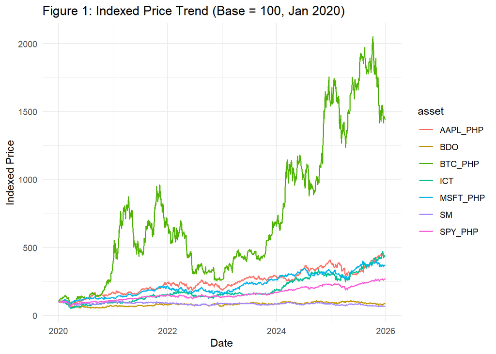

```r
indexed_prices <- prices_php|>
  select(date, BDO, ICT, SM, AAPL_PHP, MSFT_PHP, BTC_PHP, SPY_PHP) |>
  mutate(across(-date, ~ .x / first(.x) * 100)) |>
  tidyr::pivot_longer(-date, names_to = "asset", values_to = "indexed_price")

ggplot(indexed_prices, aes(x = date, y = indexed_price, color = asset)) +
  geom_line(linewidth = 0.7, na.rm = TRUE) +
  labs(
    title = "Figure 1: Indexed Price Trend (Base = 100, Jan 2020)",
    x = "Date",
    y = "Indexed Price"
  ) +
  theme_minimal()
```

#### Figure 3.2: Daily Return Distribution

Displays the distribution of daily returns per asset through the use of histograms. Every asset tends to follow a normal distribution, and are centered around the 0.0 range. However, the range of these returns varies greatly, as seen in the visualizations for BTC, which reaches as low as a -50% return and as high as a 25% return due to its high volatility and variance. Conversely, our benchmark asset SPY has a very small range, peaking at approximately ±10% return.

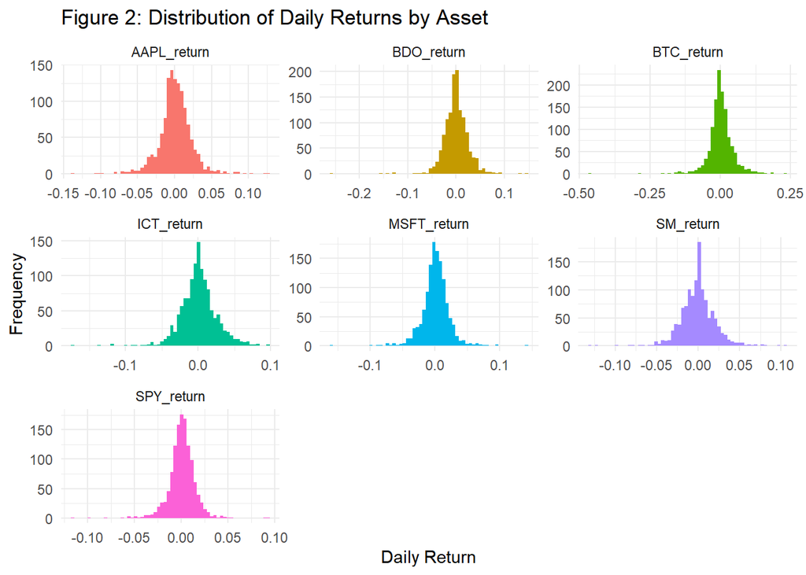

```r
returns_long_viz <-  prices_php|>
  select(date, BDO_return, ICT_return, SM_return, AAPL_return, MSFT_return, BTC_return, SPY_return) |>
  tidyr::pivot_longer(-date, names_to = "asset", values_to = "return")

ggplot(returns_long_viz, aes(x = return, fill = asset)) +
  geom_histogram(bins = 60) +
  facet_wrap(~asset, scales = "free") +
  labs(
    title = "Figure 2: Distribution of Daily Returns by Asset",
    x = "Daily Return",
    y = "Frequency"
  ) +
  theme_minimal() +
  theme(legend.position = "none")
```

#### Figure 3.3: 30-Day Rolling Volatility

Shows the volatility of each asset as time passes, since volatility is itself an ever-changing aspect of an asset. An example of this is seen in the volatility of BTC. While its overall volatility was shown to be significantly higher than the rest of the assets in the descriptive statistics, it can be observed that its volatility began to stabilize over the years, eventually reaching a level of volatility similar to those of assets like ICT and BDO. Generally, the assets all reached the peak of their volatility during 2020, most likely due to the COVID-19 market crashes. However, they have all become somewhat stable since then, with SM, MSFT, and most notably SPY having the lowest volatility as of 2026.

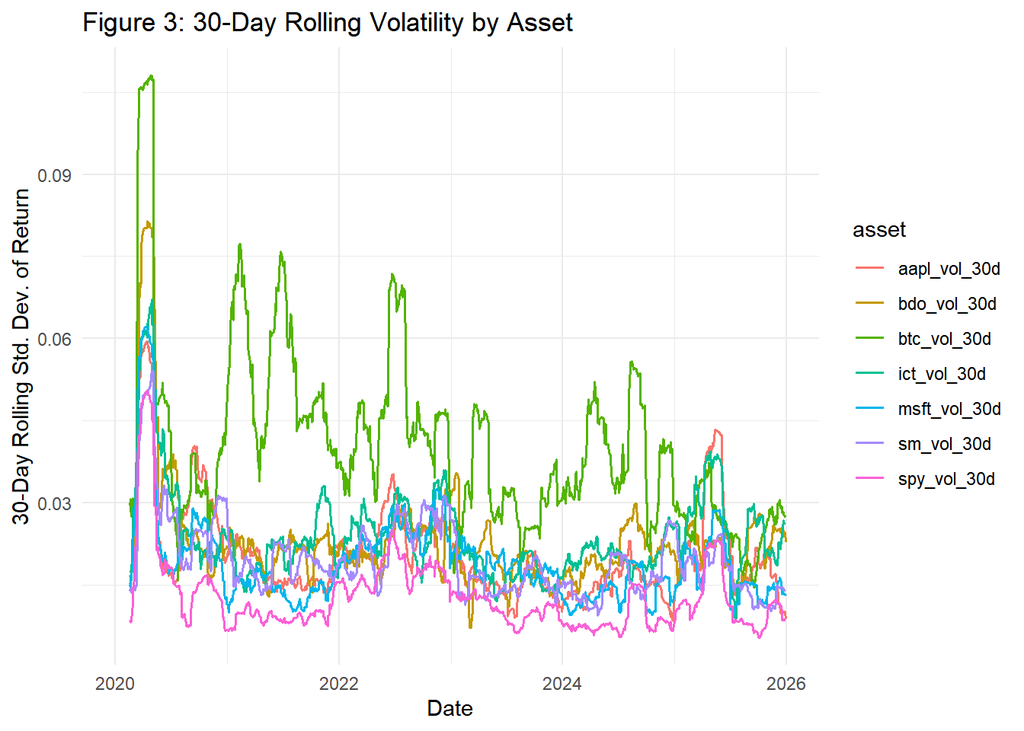

```r
rolling_vol <- prices_php |>
  arrange(date) |>
  mutate(
    bdo_vol_30d = zoo::rollapply(BDO_return, width = 30, FUN = sd, fill = NA, align = "right"),
    ict_vol_30d = zoo::rollapply(ICT_return, width = 30, FUN = sd, fill = NA, align = "right"),
    sm_vol_30d = zoo::rollapply(SM_return, width = 30, FUN = sd, fill = NA, align = "right"),
    aapl_vol_30d = zoo::rollapply(AAPL_return, width = 30, FUN = sd, fill = NA, align = "right"),
    msft_vol_30d = zoo::rollapply(MSFT_return, width = 30, FUN = sd, fill = NA, align = "right"),
    btc_vol_30d = zoo::rollapply(BTC_return, width = 30, FUN = sd, fill = NA, align = "right"),
    spy_vol_30d = zoo::rollapply(SPY_return, width = 30, FUN = sd, fill = NA, align = "right")
  ) |>
  select(date, bdo_vol_30d, ict_vol_30d, sm_vol_30d, aapl_vol_30d, msft_vol_30d, btc_vol_30d, spy_vol_30d) |>
  tidyr::pivot_longer(-date, names_to = "asset", values_to = "rolling_vol")

ggplot(rolling_vol, aes(x = date, y = rolling_vol, color = asset)) +
  geom_line(linewidth = 0.6, na.rm = TRUE) +
  labs(
    title = "Figure 3: 30-Day Rolling Volatility by Asset",
    x = "Date",
    y = "30-Day Rolling Std. Dev. of Return"
  ) +
  theme_minimal()
```

#### Figure 3.4: Correlation Heatmap

Displays the correlation between the daily returns of each individual asset pair. All of the correlations are positive, with incredibly strong correlations for the SPY-MSFT, SPY-AAPL, and AAPL-MSFT pairs, reaching as high as 0.8 correlation. The Philippine-based assets also share a moderate correlation with each other, around the 0.3-0.4 range.

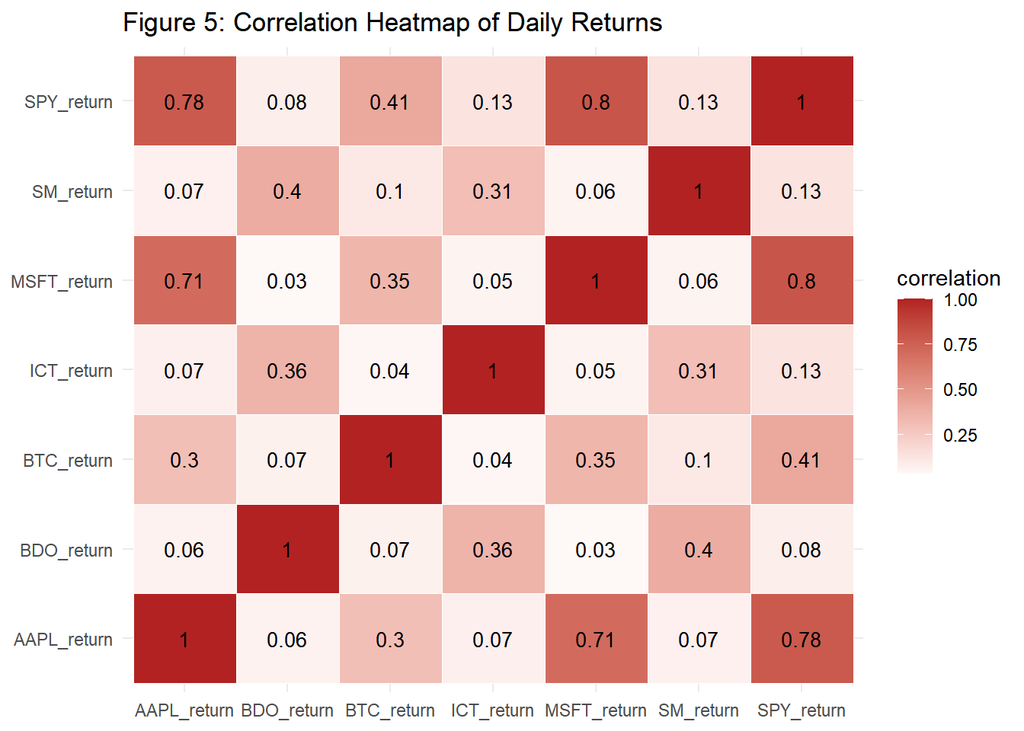

```r
corr_df <- as.data.frame(correlation_matrix) |>
  tibble::rownames_to_column("asset1") |>
  tidyr::pivot_longer(-asset1, names_to = "asset2", values_to = "correlation")

ggplot(corr_df, aes(x = asset1, y = asset2, fill = correlation)) +
  geom_tile(color = "white") +
  geom_text(aes(label = round(correlation, 2)), size = 3.5) +
  scale_fill_gradient2(low = "steelblue", mid = "white", high = "firebrick", midpoint = 0) +
  labs(
    title = "Figure 5: Correlation Heatmap of Daily Returns",
    x = NULL,
    y = NULL
  ) +
  theme_minimal()
```

**Comparing Results and Volatility Across Assets**

```r
return_vol_summary <- returns_long_viz |>
  group_by(asset) |>
  summarise(
    avg_daily_return = mean(return, na.rm = TRUE),
    annualized_return = mean(return, na.rm = TRUE) * 252,
    daily_volatility = sd(return, na.rm = TRUE),
    annualized_volatility = sd(return, na.rm = TRUE) * sqrt(252)
  ) |>
  arrange(desc(annualized_return))

data.frame(return_vol_summary)
```

```
##         asset avg_daily_return annualized_return daily_volatility
## 1  BTC_return     0.0021294614        0.53662428       0.04339060
## 2 AAPL_return     0.0011761026        0.29637787       0.02215693
## 3  ICT_return     0.0011754388        0.29621059       0.02531434
## 4 MSFT_return     0.0010421553        0.26262314       0.02064560
## 5  SPY_return     0.0007837516        0.19750539       0.01448204
## 6  BDO_return    -0.0001074582       -0.02707948       0.02493050
## 7   SM_return    -0.0003157607       -0.07957170       0.02060161
##   annualized_volatility
## 1             0.6888044
## 2             0.3517304
## 3             0.4018527
## 4             0.3277387
## 5             0.2298953
## 6             0.3957595
## 7             0.3270405
```

The table above compares the average daily and annual returns and volatility of each stock. Based on our previous explorations of descriptive statistics and data visualization, this lines up with our findings. BTC has the both the highest return and volatility across all of the assets, while AAPL, MSFT, and ICT all cluster together with similar values. SM and BDO still perform poorly, averaging negative returns while still being fairly volatile, especially in BDO’s case. When using SPY as a benchmark for the performance of the other assets, SM and BDO are the only stocks to perform worse than it.

Based on our findings, the following profiles emerge for each major type of asset:

SPY (benchmark): SPY acts as a benchmark thanks to its low volatility, average returns, and good stability. When comparing its performance to the other assets, it tends to sit in the middle.

Philippine Stocks (BDO, SM, ICT): ICT is the most worthwhile investment among the Philippine stocks, with a low correlation to the international stocks and an average return that can compete with them. Unfortunately, BDO and SM do not seem to be worth investing in due to their negative average return is moderate volatility and skewness.

International Stocks (AAPL, MSFT): The international stocks follow similar trends with a strong correlation due to their shared location and industry. While they do not offer much diversification when purchased together, they are still fairly stable with good returns.

Crypto (BTC): The most volatile, high risk high reward asset option. However, it is worth noting that its volatility has seemed to stabilize to relatively similar levels to the international stocks.

# 4. Portfolio Construction

We construct a portfolio using these 6 assets: BDO, ICT, SM, AAPL, MSFT, and BTC. We start with building a returns matrix as each optimization technique (Efficient Frontier, Global Minimum Variance, and Maximum Sharpe) relies on return data.

```r
ret_data <- prices_php |>
  select(date, ends_with("_return"), -SPY_return) |>
  na.omit()

assets <- c("BDO", "ICT", "SM", "AAPL", "MSFT", "BTC")

returns <- as.matrix(select(ret_data, ends_with("_return")))
colnames(returns) <- assets

n_assets <- length(assets)

print(n_assets)
```

```
## [1] 6
```

```r
data.frame(head(returns))
```

```
##            BDO          ICT           SM         AAPL          MSFT         BTC
## 2  0.006472515  0.041437190  0.011483380 -0.011672429 -0.0144328266  0.04826856
## 3  0.000000000 -0.003696862 -0.010521379  0.017052740  0.0116968266  0.06528139
## 4  0.000000000 -0.018692133  0.025630259 -0.002797294 -0.0072420978  0.05144410
## 5 -0.019544596 -0.005297023 -0.011310205  0.012434126  0.0122784488 -0.01384591
## 6  0.000000000  0.016554178  0.015985296  0.010338528  0.0017363965 -0.03584441
## 7  0.006557401 -0.011257155  0.006508624  0.006346370 -0.0005501291  0.03992433
```

We annualize the mean return vector and covariance matrix, since all our optimization and risk targets are expressed on an annual basis.

```r
#expected return vector
mu <- colMeans(returns) * 252

# risk
Sigma <- cov(returns) * 252

data.frame(Asset = assets, `Annual Return (%)` = round(mu * 100, 2), check.names = FALSE)
```

```
##      Asset Annual Return (%)
## BDO    BDO             -2.71
## ICT    ICT             29.62
## SM      SM             -7.96
## AAPL  AAPL             29.64
## MSFT  MSFT             26.26
## BTC    BTC             53.66
```

To see the effects of optimization on our portfolio, we create a baseline of a a simple equal weighted portfolio, with and without re-balancing. This baseline gives us something to compare our optimized portfolios against.

```r
portfolio_growth <- function(weights, ret_df = ret_data, rebalance = FALSE) {
  dates <- ret_df$date
  rets <- as.matrix(select(ret_df, ends_with("_return")))

  if (!rebalance) {
    asset_growth <- apply(rets, 2, function(r) cumprod(1 + r))
    port_value <- as.numeric(asset_growth %*% weights)
  } else {
    month_id <- format(dates, "%Y-%m")
    port_value <- numeric(length(dates))
    value <- 1
    holdings <- value * weights

    for (i in seq_along(dates)) {
      if (i > 1 && month_id[i] != month_id[i - 1]) {
        holdings <- value * weights
      }
      holdings <- holdings * (1 + rets[i, ])
      value <- sum(holdings)
      port_value[i] <- value
    }
  }

  tibble(date = dates, value = port_value)
}
```

We re-balance because prices move and starts pulling the actual portfolio away from that optimum. Over time, some assets grow faster than others which can shift the target mix and exposes the assets to more risk than planned.

```r
eq_weights <- rep(1 / n_assets, n_assets)

eq_no_rebal <- portfolio_growth(eq_weights, rebalance = FALSE) |> mutate(portfolio = "Equal Weight (No Rebalance)")
eq_rebal <- portfolio_growth(eq_weights, rebalance = TRUE)  |> mutate(portfolio = "Equal Weight (Monthly Rebalance)")
```

Lastly, we initialize equal weighing among the assets and call `portfolio_growth()` to create paths with and without monthly rebalancing.

# 5. Portfolio Optimization

With the return matrix and baseline established, we now solve for the three portfolios, the Efficient Frontier, the Global Minimum Variance (GMV) Portfolio, and the Maximum Sharpe Portfolio. We use the `quadprog` (quadratic programming) library to help with portfolio optimization. In general, these 3 techniques or theories all aim to achieve a singular goal, that being how to best balance or optimize the ratio of returns given risks in its own way.

## Efficient Frontier

The efficient frontier is a core concept in Modern Portfolio Theory (MPT) introduced by Harry Markowitz in 1952. It is a curved line on a graph that shows the best investment portfolios, these portfolios give the highest expected return for a set level of risk, or the lowest risk for a set level of return.

We trace the frontier by minimizing variance for a grid of target returns spanning the achievable range.

```r
Dmat <- 2 * Sigma
dvec <- rep(0, n_assets)
```

```r
target_rets <- seq(min(mu), max(mu), length.out = 100)

eff_frontier <- map_dfr(target_rets, function(tr) {
  Amat_ef <- cbind(rep(1, n_assets), mu, diag(n_assets))
  bvec_ef <- c(1, tr, rep(0, n_assets))

  sol <- tryCatch(solve.QP(Dmat, dvec, Amat_ef, bvec_ef, meq = 2),
                   error = function(e) NULL)
  if (is.null(sol)) return(NULL)

  w <- sol$solution
  tibble(
    target_ret = tr,
    ret = sum(w * mu),
    vol = as.numeric(sqrt(t(w) %*% Sigma %*% w)),
    sharpe = (sum(w * mu) - rf_annual) / as.numeric(sqrt(t(w) %*% Sigma %*% w)),
    weights = list(setNames(w, assets))
  )
})
```

## Global Minimum Variance Portfolio

A Global Minimum Variance (GMV) Portfolio is a specialized asset mix built from a set of risky investments that achieves the lowest possible total risk or price volatility (variance). It sits at the absolute leftmost point of the efficient frontier curve in MPT.

The GMV portfolio minimizes `w'Σw` subject to weights summing to 1.

```r
Amat <- cbind(rep(1, n_assets), diag(n_assets))   # sum(w) = 1, w_i >= 0
bvec <- c(1, rep(0, n_assets))

gmv_sol <- solve.QP(Dmat, dvec, Amat, bvec, meq = 1)
gmv_weights <- setNames(gmv_sol$solution, assets)

gmv_ret <- sum(gmv_weights * mu)
gmv_vol <- as.numeric(sqrt(t(gmv_weights) %*% Sigma %*% gmv_weights))

data.frame(Weight = round(gmv_weights, 4))
```

```
##      Weight
## BDO  0.1327
## ICT  0.1463
## SM   0.2855
## AAPL 0.1411
## MSFT 0.2891
## BTC  0.0053
```

## Maximum Sharpe Portfolio

A Maximum Sharpe Portfolio is the optimal asset allocation on the efficient frontier that delivers the highest possible excess return per unit of total risk (volatility).

```r
max_sharpe_row <- eff_frontier |> slice_max(sharpe, n = 1)
max_sharpe_weights <- max_sharpe_row$weights[[1]]

data.frame(Weight = round(max_sharpe_weights, 4))
```

```
##      Weight
## BDO  0.0000
## ICT  0.3692
## SM   0.0000
## AAPL 0.2891
## MSFT 0.1495
## BTC  0.1922
```

The Maximum Sharpe portfolio notably excludes BDO and SM from the allocation, likely due to their poor returns given their volatility levels. ICT and AAPL are given the largest allocations thanks to their comparatively high returns for their volatility levels. BTC is given a more conservative allocation due to its high volatility, but not excluded due to its comparatively high returns. MSFT also gets a relatively conservative allocation due to its lower returns compared to ICT and AAPL.

#### Figure 5.1: Efficient Frontier Chart

We visualize the frontier together with the individual assets, the key portfolios, and the capital allocation line through the tangency point.

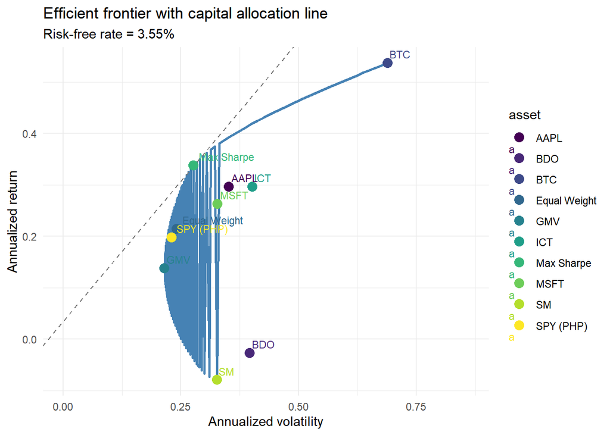

```r
# CML slope through the tangency (max-Sharpe) portfolio
slope_cml <- (max_sharpe_row$ret - rf_annual) / max_sharpe_row$vol

# Annualized points: assets, then the key portfolios
asset_pts <- data.frame(
  asset = assets,
  ret   = colMeans(returns) * 252,
  vol   = apply(returns, 2, sd) * sqrt(252)
)

eq_ret <- as.matrix(select(ret_data, ends_with("_return"))) %*% eq_weights

key_pts <- rbind(
  asset_pts,
  data.frame(asset = "Equal Weight", ret = mean(eq_ret) * 252,  vol = sd(eq_ret) * sqrt(252)),
  data.frame(asset = "GMV",          ret = gmv_ret,             vol = gmv_vol),
  data.frame(asset = "Max Sharpe",   ret = max_sharpe_row$ret,  vol = max_sharpe_row$vol),
  data.frame(asset = "SPY (PHP)",    ret = mean(rets_wide$SPY_return) * 252,
                                     vol = sd(rets_wide$SPY_return) * sqrt(252))
)

eff_frontier |>
  arrange(vol) |>                            # safe even with NULL unfeasible gaps
  ggplot(aes(vol, ret)) +
  geom_line(color = "steelblue", linewidth = 1) +
  geom_abline(intercept = rf_annual, slope = slope_cml,
              linetype = "dashed", color = "grey45") +
  geom_point(data = key_pts, aes(color = asset), size = 3.5) +
  geom_text(data = key_pts, aes(label = asset, color = asset),
            hjust = -0.1, vjust = -0.6, size = 3) +
  scale_color_viridis_d() +
  labs(title = "Efficient frontier with capital allocation line",
       subtitle = paste0("Risk-free rate = ", round(rf_annual * 100, 2), "%"),
       x = "Annualized volatility", y = "Annualized return") +
  theme_minimal() +
  coord_cartesian(xlim = c(0, max(key_pts$vol, eff_frontier$vol) * 1.25))
```

SM and BDO notably fall vastly below the efficient frontier; an investor taking on the risk that SM has would be much better off if they instead allocate that money to MSFT, as it provides a much higher return for the same risk. A similar observation can be made between BDO and ICT. However, holding a small allocation in these assets may still prove beneficial for diversification. These two securities are in vastly different industries compared to the others, which may be helpful when the other securities experience periods of drawdown.

## Cross-Portfolio Visualizations

Section 3 already visualized prices, returns, and correlation at the individual-asset level, so the visualizations below instead look at the three constructed strategies (Equal-Weight, GMV, and Max Sharpe) as portfolios in their own right. Since none of the three has a price series pulled directly, we first build each strategy’s own daily return series from the asset-level `returns` matrix and its respective weights.

```r
port_returns <- tibble(
  date = ret_data$date,
  `Equal-Weight` = as.numeric(returns %*% eq_weights),
  `GMV` = as.numeric(returns %*% gmv_weights),
  `Max Sharpe` = as.numeric(returns %*% max_sharpe_weights)
)

port_returns_long <- port_returns |>
  tidyr::pivot_longer(-date, names_to = "portfolio", values_to = "return")

data.frame(head(port_returns))
```

```
##         date Equal.Weight          GMV   Max.Sharpe
## 1 2020-01-03  0.013592732  0.004636949 0.0190438450
## 2 2020-01-06  0.013302119  0.002589801 0.0178619896
## 3 2020-01-07  0.008057140  0.002370304 0.0010961775
## 4 2020-01-08 -0.004214193 -0.001367840 0.0008133699
## 5 2020-01-09  0.001461665  0.008755265 0.0024705784
## 6 2020-01-10  0.007921574  0.002030922 0.0052707854
```

A separate per-portfolio indexed price plot is not needed here, Figure 5.5 below already shows each strategy’s cumulative growth path, which is the portfolio-level equivalent of the indexed price plot in Figure 3.1.

#### Figure 5.2: Daily Return Plot

Figure 3.2 and Figure 3.3 covered the *distribution* and rolling volatility of daily returns per asset; this chart instead plots each **portfolio’s** daily return series across time, making it possible to see directly whether GMV’s return path actually looks calmer day-to-day than Equal-Weight and Max Sharpe’s, rather than inferring it from the six separate asset panels.

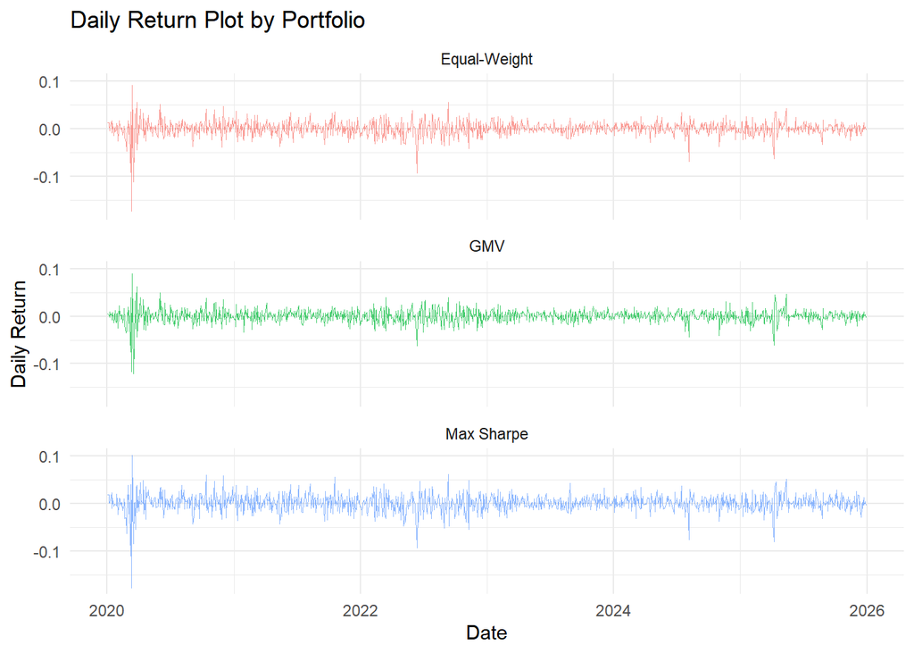

```r
ggplot(port_returns_long, aes(x = date, y = return, color = portfolio)) +
  geom_line(alpha = 0.7, linewidth = 0.3, na.rm = TRUE) +
  facet_wrap(~portfolio, ncol = 1) +
  labs(
    title = "Daily Return Plot by Portfolio",
    x = "Date",
    y = "Daily Return"
  ) +
  theme_minimal() +
  theme(legend.position = "none")
```

With all three portfolios plotted on the same y-axis, the chart makes the volatility ordering from the descriptive statistics table directly visible day-by-day rather than compressed into a single number. The Equal-Weight and Max Sharpe panels both show a materially larger spike around the March 2020 crash and continue showing taller day-to-day swings through the rest of the sample, while the GMV panel stays visibly more compressed around zero throughout. This tracks Max Sharpe’s larger BTC and ICT/AAPL allocations, both of which amplify single-day moves, against GMV’s heavier, more diversified Philippine-stock tilt. It’s the same story as GMV’s 1.35% daily standard deviation versus Max Sharpe’s 1.74% from the Portfolio Descriptive Statistics table in Section 6, just made visible as a return path instead of a summary statistic.

#### Figure 5.3: Correlation Heatmap

Figure 3.4 showed how the six individual assets correlate with one another. Since all three portfolios are built from overlapping subsets of the same six assets, this chart instead shows how correlated the three **portfolios’** return series are with each other, which is a useful check on how much genuine diversification the optimization actually bought us versus how much the three strategies just move together.

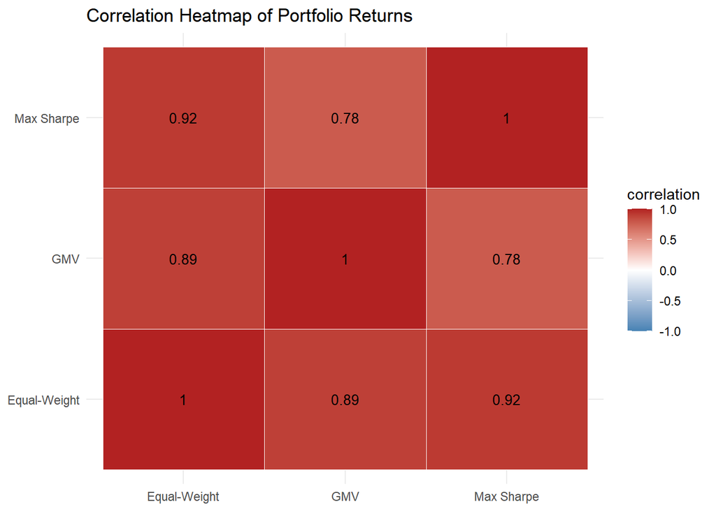

```r
port_corr_matrix <- port_returns |>
  select(-date) |>
  cor(use = "complete.obs")

port_corr_df <- as.data.frame(port_corr_matrix) |>
  tibble::rownames_to_column("portfolio1") |>
  tidyr::pivot_longer(-portfolio1, names_to = "portfolio2", values_to = "correlation")

ggplot(port_corr_df, aes(x = portfolio1, y = portfolio2, fill = correlation)) +
  geom_tile(color = "white") +
  geom_text(aes(label = round(correlation, 2)), size = 3.5) +
  scale_fill_gradient2(low = "steelblue", mid = "white", high = "firebrick",
                        midpoint = 0, limits = c(-1, 1)) +
  labs(
    title = "Correlation Heatmap of Portfolio Returns",
    x = NULL,
    y = NULL
  ) +
  theme_minimal()
```

#### Figure 5.4: Portfolio Allocation

This chart compares how each of the three portfolio strategies (Equal Weight, GMV, Max Sharpe) splits its weight across the 6 assets, making the optimization results from the previous section directly visible side by side rather than as three separate tables.

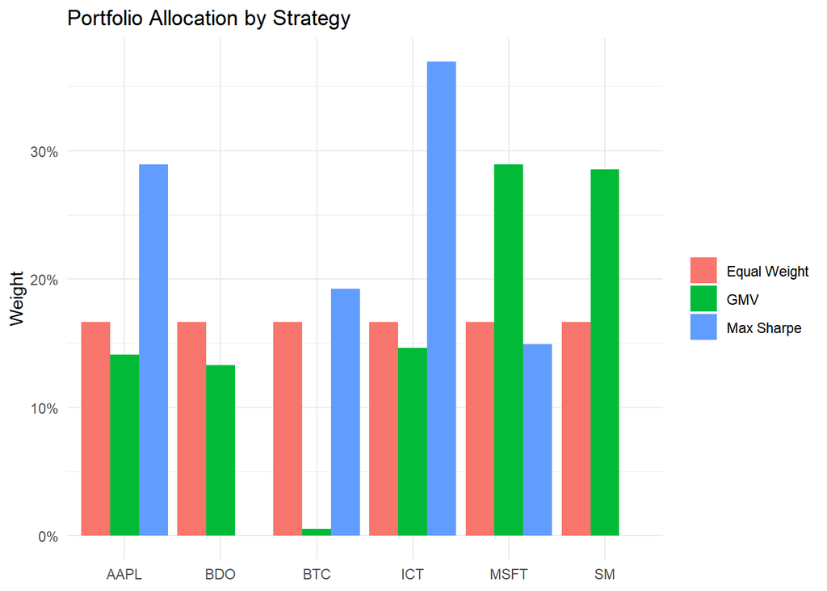

```r
alloc_df <- bind_rows(
  tibble(asset = assets, weight = eq_weights, portfolio = "Equal Weight"),
  tibble(asset = assets, weight = as.numeric(gmv_weights), portfolio = "GMV"),
  tibble(asset = assets, weight = as.numeric(max_sharpe_weights), portfolio = "Max Sharpe")
)

ggplot(alloc_df, aes(x = asset, y = weight, fill = portfolio)) +
  geom_col(position = "dodge") +
  scale_y_continuous(labels = scales::percent) +
  labs(
    title = "Portfolio Allocation by Strategy",
    x = NULL,
    y = "Weight",
    fill = NULL
  ) +
  theme_minimal()
```

#### Figure 5.5: Optimized Portfolio Growth Comparison

`portfolio_growth()` was only called on the equal-weight portfolio earlier (`eq_no_rebal`, `eq_rebal`). Before this chart can compare all three strategies, the GMV and Max Sharpe portfolios need their own growth paths computed the same way, with and without monthly re-balancing.

```r
gmv_no_rebal <- portfolio_growth(gmv_weights, rebalance = FALSE) |>
  mutate(portfolio = "GMV (No Rebalance)")
gmv_rebal <- portfolio_growth(gmv_weights, rebalance = TRUE) |>
  mutate(portfolio = "GMV (Monthly Rebalance)")

sharpe_no_rebal <- portfolio_growth(max_sharpe_weights, rebalance = FALSE) |>
  mutate(portfolio = "Max Sharpe (No Rebalance)")
sharpe_rebal <- portfolio_growth(max_sharpe_weights, rebalance = TRUE) |>
  mutate(portfolio = "Max Sharpe (Monthly Rebalance)")

all_growth <- bind_rows(
  eq_no_rebal, eq_rebal,
  gmv_no_rebal, gmv_rebal,
  sharpe_no_rebal, sharpe_rebal
)

data.frame(head(all_growth))
```

```
##         date    value                   portfolio
## 1 2020-01-03 1.013593 Equal Weight (No Rebalance)
## 2 2020-01-06 1.027313 Equal Weight (No Rebalance)
## 3 2020-01-07 1.036258 Equal Weight (No Rebalance)
## 4 2020-01-08 1.031539 Equal Weight (No Rebalance)
## 5 2020-01-09 1.032159 Equal Weight (No Rebalance)
## 6 2020-01-10 1.040845 Equal Weight (No Rebalance)
```

With all six growth paths available, we can now compare rebalanced versus non-rebalanced performance across all three strategies on one chart.

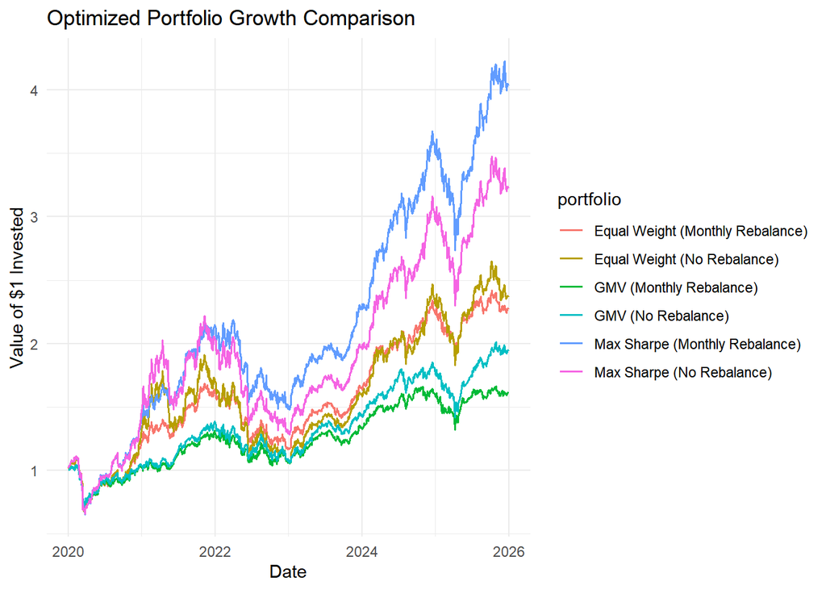

```r
ggplot(all_growth, aes(x = date, y = value, color = portfolio)) +
  geom_line(linewidth = 0.6, na.rm = TRUE) +
  labs(
    title = "Optimized Portfolio Growth Comparison",
    x = "Date",
    y = "Value of $1 Invested"
  ) +
  theme_minimal()
```

#### Indexed Portfolio Growth vs SPY

The previous figure showed the absolute growth of one dollar invested per strategy. This chart instead indexes each portfolio to a base of 100 on the first day of the sample, the portfolio-level equivalent of the per-asset indexed price trend seen previously, and plots it against the SPY benchmark on the same scale for a direct comparison of relative performance.

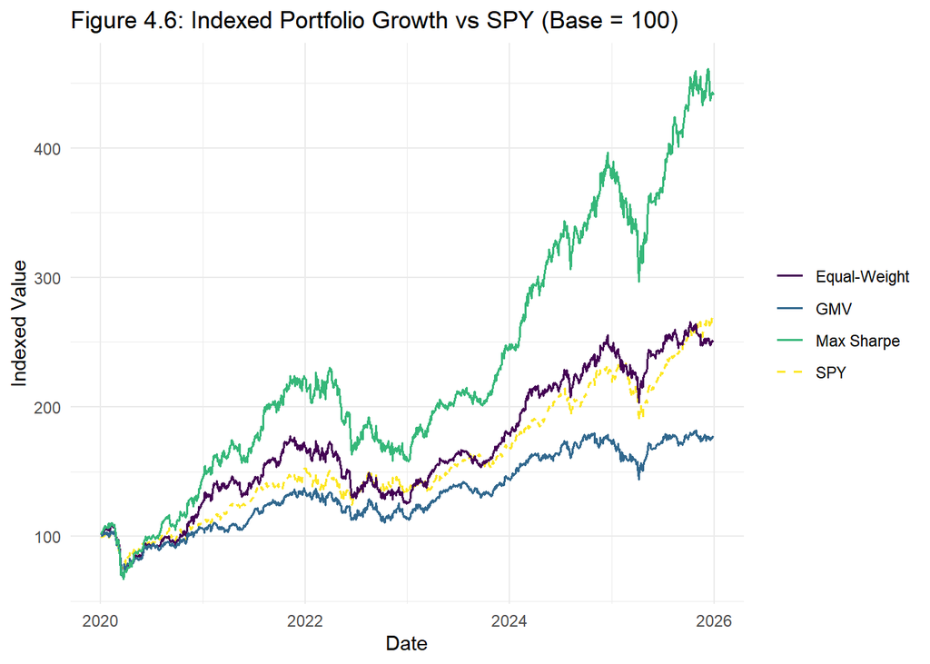

```r
indexed_port_returns <- port_returns |>
  mutate(across(-date, ~ cumprod(1 + .x) * 100)) |>
  inner_join(
    prices_php |>
      transmute(date = date, SPY = SPY_PHP / first(SPY_PHP) * 100),
    by = "date"
  ) |>
  tidyr::pivot_longer(-date, names_to = "portfolio", values_to = "indexed_value")

ggplot() +
  geom_line(data = filter(indexed_port_returns, portfolio == "SPY"),
            aes(x = date, y = indexed_value, color = portfolio),
            linewidth = 0.7, linetype = "dashed", na.rm = TRUE) +
  geom_line(data = filter(indexed_port_returns, portfolio != "SPY"),
            aes(x = date, y = indexed_value, color = portfolio),
            linewidth = 0.7, na.rm = TRUE) +
  labs(
    title = "Figure 4.6: Indexed Portfolio Growth vs SPY (Base = 100)",
    x = "Date",
    y = "Indexed Value",
    color = NULL
  ) +
  scale_color_viridis_d() +
  theme_minimal()
```

# 6. Portfolio Risk Assessment

Having constructed the Equal-Weight, GMV, and Maximum Sharpe portfolios, this section evaluates each one across three angles: descriptive statistics per portfolio, formal risk evaluation, and supporting visualizations.

We start with descriptive statistics for each portfolio’s daily return series, mirroring the per-asset descriptive statistics from Section 3, but now applied to the three constructed portfolios instead of the six individual assets. We then move into formal risk management techniques, specifically Historical VaR, Parametric VaR, Expected Shortfall (CVaR), Monte Carlo Simulation, and Stress Testing, each paired with a supporting visualization.

The daily portfolio return series used throughout this section, `port_returns`, was already assembled in Section 5 alongside the cross-portfolio visualizations, so we simply reuse it here as the raw input for every measure below, along with a standard 95% confidence level.

```r
conf_level <- 0.95
```

## Portfolio Descriptive Statistics

Just as Section 3 profiled each asset’s daily returns individually, we profile each portfolio’s daily returns here, this shows how much the optimization step actually changed the portfolio’s risk-return profile relative to naive equal weighting, ahead of the formal risk measures below.

```r
port_summary <- port_returns |>
  tidyr::pivot_longer(-date, names_to = "portfolio", values_to = "ret") |>
  group_by(portfolio) |>
  summarise(
    `Mean Daily Ret (%)` = mean(ret, na.rm = TRUE) * 100,
    `SD Daily Ret (%)`   = sd(ret, na.rm = TRUE) * 100,
    `Ann. Ret (%)`       = mean(ret, na.rm = TRUE) * 252 * 100,
    `Ann. Vol (%)`       = sd(ret, na.rm = TRUE) * sqrt(252) * 100,
    Sharpe               = (mean(ret, na.rm = TRUE) * 252 - rf_annual) /
                           (sd(ret, na.rm = TRUE) * sqrt(252)),
    `Max Drawdown (%)`   = { r <- ret[!is.na(ret)];
                       min(cumprod(1 + r) / cummax(cumprod(1 + r)) - 1) * 100 }
  ) |>
  ungroup()

data.frame(port_summary)
```

```
##      portfolio Mean.Daily.Ret.... SD.Daily.Ret.... Ann..Ret.... Ann..Vol....
## 1 Equal-Weight         0.08499899         1.517261     21.41974     24.08578
## 2          GMV         0.05460466         1.354968     13.76038     21.50945
## 3   Max Sharpe         0.13390866         1.743142     33.74498     27.67152
##      Sharpe Max.Drawdown....
## 1 0.7417686        -36.36021
## 2 0.4745217        -34.00035
## 3 1.0910608        -39.11243
```

## Historical VaR

Historical value at risk is a simple non-parametric approach towards estimating a portfolio’s maximum loss through simply sorting the portfolio’s actual daily returns from worst to best. It then assumes that history will repeat itself as far as the portfolio’s risk is concerned.

We compute historical VaR as the portfolio value multiplied against the quantile of the confidence score (1-a)

```r
historical_var <- port_returns |>
  summarise(across(
    c(`Equal-Weight`, GMV, `Max Sharpe`),
    ~ -quantile(.x, probs = 1 - conf_level, na.rm = TRUE)
  ))


data.frame(Portfolio = names(historical_var),
            `Daily Historical VaR (95%)` = round(as.numeric(historical_var), 4),
            check.names = FALSE)
```

```
##      Portfolio Daily Historical VaR (95%)
## 1 Equal-Weight                     0.0211
## 2          GMV                     0.0195
## 3   Max Sharpe                     0.0250
```

At a 95% confidence level, the GMV portfolio has the lowest historical VaR while maximum Sharpe has the highest, while the equal weighted portfolio sits in the middle of the 2. These can be read as the loss threshold of the 5% of worst trading days per portfolio. The values adequately align with each portfolio’s objective, GMV was explicitly optimized to minimize portfolio variance, hence translating to a tighter distribution creating smaller loss at any given percentile. On the other hand, maximum Sharpe was meant to optimize return per unit of risk, meaning the portfolio likely leans more towards higher expected returns which, in turn, results in higher volatility. Having a higher VaR is not necessarily bad, the extra risk should be judged to see if the risk to return trade-off is evenly compensated.

## Parametric VaR

Parametric value at risk uses mean-variance analysis and other statistical inferences based on past information to predict future outcomes. This measures potential financial losses by assuming portfolio returns fit a normal distribution.

We compute parametric VaR by multiplying the portfolio value against (z-score * standard deviation - mean)

```r
z_score <- qnorm(1 - conf_level)

parametric_var <- port_returns |>
  summarise(across(
    c(`Equal-Weight`, GMV, `Max Sharpe`),
    ~ -(mean(.x, na.rm = TRUE) + z_score * sd(.x, na.rm = TRUE))
  ))

data.frame(Portfolio = names(parametric_var),
            `Daily Parametric VaR (95%)` = round(as.numeric(parametric_var), 4),
            check.names = FALSE)
```

```
##      Portfolio Daily Parametric VaR (95%)
## 1 Equal-Weight                     0.0241
## 2          GMV                     0.0217
## 3   Max Sharpe                     0.0273
```

The parametric VaR per portfolio follows a similar pattern to that of historical VaR, the GMV portfolio has the lowest parametric VaR while maximum Sharpe remains the highest. Across all 3 portfolios, parametric VaR consistently exceeds historical VaR by roughly 0.2–0.3 percentage values. This could indicate that the assumed normal distribution slightly overstates daily risk relative to what has been empirically observed. Because the difference is consistent among all portfolios, this could just be an effect of the sample period, especially considering the global events of the given time period.

## Expected Shortfall (CVaR)

Given a less stable investment, standard VaR may not be sufficient to assess the full picture of the risks involved. CVaR represents the expected loss if the worst-case threshold of VaR is crossed, giving insight into what happens beyond the VaR breakpoint.

We compute expected shortfall through the summation of individual portfolio returns multiplied by observational probability.

```r
expected_shortfall <- port_returns |>
  summarise(across(
    c(`Equal-Weight`, GMV, `Max Sharpe`),
    ~ -mean(.x[.x <= quantile(.x, probs = 1 - conf_level, na.rm = TRUE)], na.rm = TRUE)
  ))


data.frame(Portfolio = names(expected_shortfall),
            `Daily Expected Shortfall (95%)` = round(as.numeric(expected_shortfall), 4),
            check.names = FALSE)
```

```
##      Portfolio Daily Expected Shortfall (95%)
## 1 Equal-Weight                         0.0350
## 2          GMV                         0.0316
## 3   Max Sharpe                         0.0403
```

## Figure 6.1: Risk Comparison per VaR

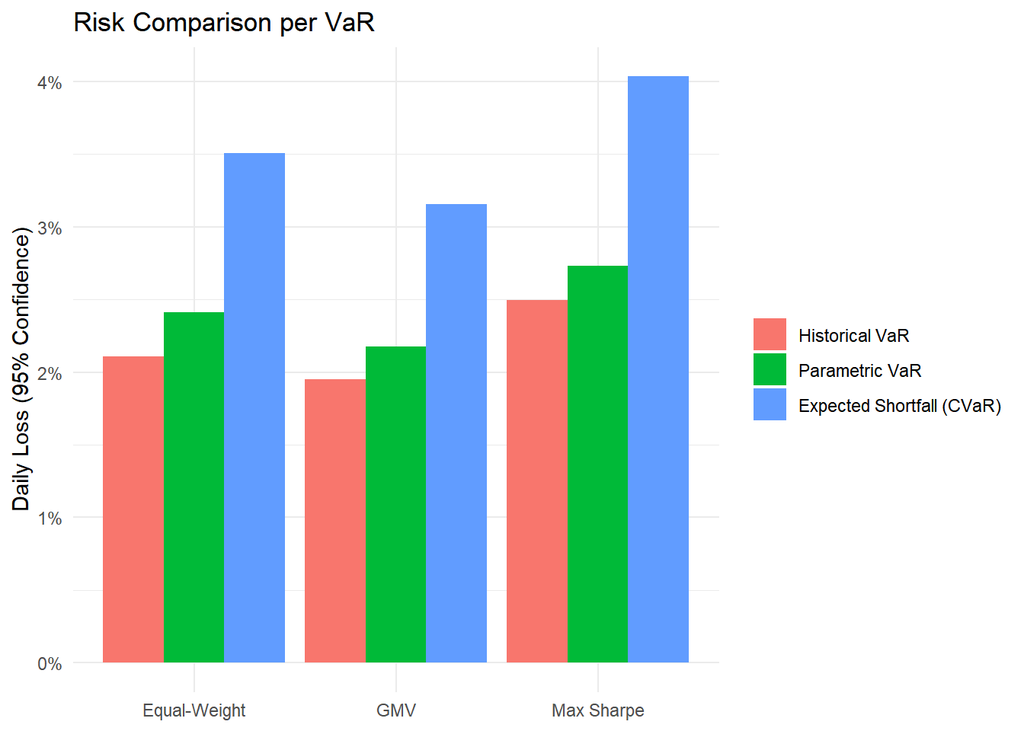

```r
var_comparison <- bind_rows(
  historical_var |>
    pivot_longer(everything(), names_to = "Portfolio", values_to = "value") |>
    mutate(Method = "Historical VaR"),
  parametric_var |>
    pivot_longer(everything(), names_to = "Portfolio", values_to = "value") |>
    mutate(Method = "Parametric VaR"),
  expected_shortfall |>
    pivot_longer(everything(), names_to = "Portfolio", values_to = "value") |>
    mutate(Method = "Expected Shortfall (CVaR)")
) |>
  mutate(Method = factor(Method, levels = c("Historical VaR", "Parametric VaR", "Expected Shortfall (CVaR)")))

ggplot(var_comparison, aes(x = Portfolio, y = value, fill = Method)) +
  geom_col(position = "dodge") +
  labs(title = "Risk Comparison per VaR",
       x = NULL, y = "Daily Loss (95% Confidence)", fill = NULL) +
  scale_y_continuous(labels = scales::percent) + theme_minimal()
```

Figure 6.1 puts all three risk measures side by side for each portfolio, and the pattern is consistent across every method: GMV’s bars are the shortest, Max Sharpe’s are the tallest, and Equal-Weight sits in between, regardless of whether the measure is Historical VaR, Parametric VaR, or CVaR. The chart also makes the CVaR gap visually obvious, for each portfolio, the Expected Shortfall bar clears both VaR bars by a wide margin, illustrating that the loss conditional on breaching the 95% threshold is meaningfully larger than the threshold itself. That the ranking of the three portfolios never flips across methods is the more important takeaway: it means the choice of risk measure doesn’t change which portfolio looks riskier, only by how much.

## Monte Carlo Simulation

We setup the Monte Carlo with the stated `RANDOM_SEED` constant and a standard of 5000 simulations. `mu_p` and `sigma_p` represent the historical mean and standard deviation of the portfolio.

```r
set.seed(RANDOM_SEED)
n_sim_val <- 5000

simulate_portfolio_var <- function(port_ret, n_sim = n_sim_val, conf = conf_level) {
  mu_p <- mean(port_ret, na.rm = TRUE)
  sigma_p <- sd(port_ret, na.rm = TRUE)

  sim_returns <- rnorm(n_sim, mean = mu_p, sd = sigma_p)

  tibble(
    VaR = -quantile(sim_returns, probs = 1 - conf),
    ES = -mean(sim_returns[sim_returns <= quantile(sim_returns, probs = 1 - conf)])
  )
}

mc_results <- bind_rows(
  simulate_portfolio_var(port_returns$`Equal-Weight`) |> mutate(Portfolio = "Equal-Weight"),
  simulate_portfolio_var(port_returns$GMV) |> mutate(Portfolio = "GMV"),
  simulate_portfolio_var(port_returns$`Max Sharpe`) |> mutate(Portfolio = "Max Sharpe")
) |> relocate(Portfolio)

data.frame(mc_results |> mutate(across(c(VaR, ES), ~ round(.x, 4))))
```

```
##      Portfolio    VaR     ES
## 1 Equal-Weight 0.0247 0.0312
## 2          GMV 0.0221 0.0272
## 3   Max Sharpe 0.0279 0.0352
```

The Monte Carlo simulations’ parametric VaR and CVaR maintain the same relative positions as those previously calculated on an individual outcome, where GMV has the lowest VaR and maximum Sharpe remaining the highest. Monte Carlo produces VaR estimates closely aligned with parametric VaR across all three portfolios, within 0.05–0.06 percentage values, which is expected given both methods share the same assumed normal distribution with some slight differences due to sampling noise. The Monte Carlo expected shortfall exceeds Monte Carlo VaR by 0.5–0.7 percentage values across portfolios, this is consistent with CVaR’s definition as the average loss beyond the VaR threshold. Lastly, the risk ordering of the 3 portfolios are consistent across all evaluated risk measures, indicating that GMV and maximum Sharpe remain as consistent findings

#### Figure 6.2: Historical vs. Monte Carlo Distribution

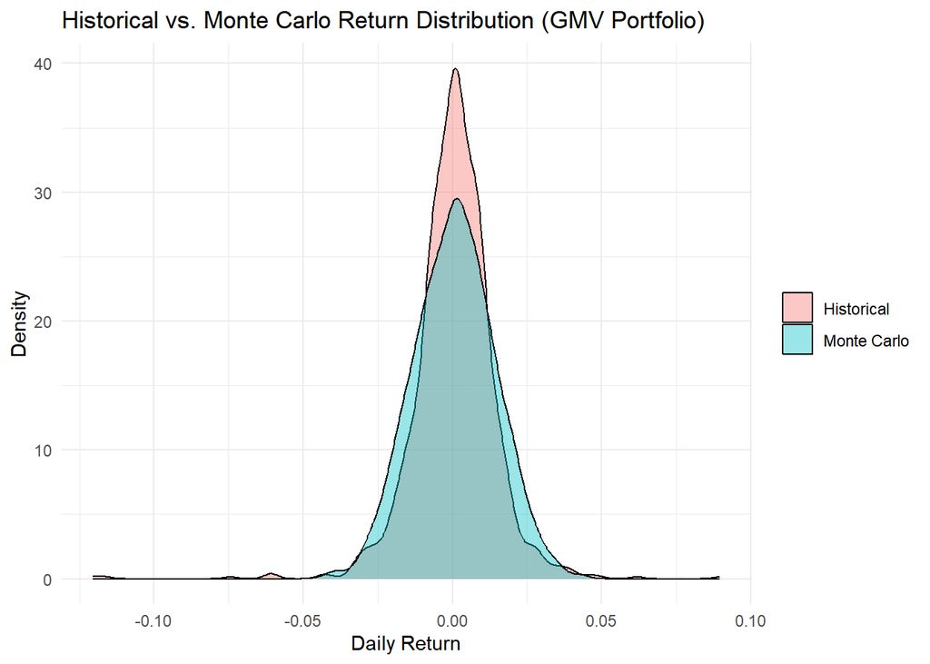

```r
sim_gmv <- rnorm(n_sim_val, mean = mean(port_returns$GMV, na.rm = TRUE),
                  sd = sd(port_returns$GMV, na.rm = TRUE))

bind_rows(
  tibble(ret = port_returns$GMV, source = "Historical"),
  tibble(ret = sim_gmv, source = "Monte Carlo")
) |>
  ggplot(aes(x = ret, fill = source)) + geom_density(alpha = 0.4) +
  labs(title = "Historical vs. Monte Carlo Return Distribution (GMV Portfolio)",
       x = "Daily Return", y = "Density", fill = NULL) + theme_minimal()
```

## Stress Testing

VaR, CVaR, and Monte Carlo simulations all describe outcomes based on statistical likelihood, stress testing applies hypothetical market stress scenarios to test and evaluate the result of a single day potential loss per portfolio. The loss was calculated as a weighted sum of asset returns influenced by the scenario stress.

We take these 5 scenarios and assign its related weights to test the portfolios and assets on given shocks

```r
stress_scenarios <- list(
  "Market-Wide Crash (-20%)"   = rep(-0.20, n_assets),
  "BTC Crash (-50%), rest flat" = c(BDO = 0, ICT = 0, SM = 0, AAPL = 0, MSFT = 0, BTC = -0.50),
  "PH Market Selloff (-15% local, flat abroad)" =
    c(BDO = -0.15, ICT = -0.15, SM = -0.15, AAPL = 0, MSFT = 0, BTC = 0),
  "International Market Selloff (-15% abroad, flat local)" =
    c(BDO = 0, ICT = 0, SM = 0, AAPL = -0.15, MSFT = -0.15, BTC = 0),
  "Global Equity Correction (-10% equities, BTC -25%)" =
    c(BDO = -0.10, ICT = -0.10, SM = -0.10, AAPL = -0.10, MSFT = -0.10, BTC = -0.25)
)
```

We then calculate stress by multiplying the weights of each portfolio against the added stress to return a single day loss percentage value.

```r
stress_test <- function(weights, scenario) {
  sum(weights * scenario)
}

stress_results <- map_dfr(names(stress_scenarios), function(scenario_name) {
  shock <- stress_scenarios[[scenario_name]]
  tibble(
    Scenario = scenario_name,
    `Equal-Weight` = stress_test(eq_weights, shock),
    GMV = stress_test(gmv_weights, shock),
    `Max Sharpe` = stress_test(max_sharpe_weights, shock)
  )
})

data.frame(stress_results |> mutate(across(where(is.numeric), ~ scales::percent(.x, accuracy = 0.1))))
```

```
##                                                 Scenario Equal.Weight    GMV
## 1                               Market-Wide Crash (-20%)       -20.0% -20.0%
## 2                            BTC Crash (-50%), rest flat        -8.3%  -0.3%
## 3            PH Market Selloff (-15% local, flat abroad)        -7.5%  -8.5%
## 4 International Market Selloff (-15% abroad, flat local)        -5.0%  -6.5%
## 5     Global Equity Correction (-10% equities, BTC -25%)       -12.5% -10.1%
##   Max.Sharpe
## 1     -20.0%
## 2      -9.6%
## 3      -5.5%
## 4      -6.6%
## 5     -12.9%
```

**Market-Wide Crash of -20%**

First, a market wide crash resulting in a -20.0% loss of all returns across portfolios is expected, regardless of how weights are distributed a -20.0% crash would result in all assets dropping by that same amount. This stress scenario serves as confirmation that calculated weights sum up to 1 over being a truly meaningful assessment of stress.

**BTC Crash of -50%**

With BTC being the most volatile asset, it is weighed differently across each portfolio and proves to be reflective of each optimization’s objective. The GMV portfolio barely takes on any loss (-0.3%) as it holds almost no amount in BTC, while maximum Sharpe and the equal weighted portfolio have relatively the same amount of loss (-9.6% and -8.3%). This confirms expected portfolio performance, GMV avoided putting too much weight into BTC due to its high volatility, while maximum Sharpe leaned into BTC’s high expected returns relative to its risk.

**Philippine Market Selloff of -15%**

To test the influence of the weight of local and international markets, a crash of -15.0% was done on the local market. GMV now performs the worst (-8.5%) despite having consistently been the safest portfolio, while maximum Sharpe performs the best with -5.5% in loss. This implies that GMV is too overweighted/biased towards Philippine equities relative to other portfolios, although the difference isn’t huge this implies lower historic volatility with Philippine stocks than international ones.

**International Market Selloff of -15%**

To further test the influence of the weight of local and international markets, a crash of -15.0% was done on the international market this time. The GMV and maximum Sharpe portfolios now show a nearly identical amount of loss (-6.5% and -6.6%) for an international market selloff. This further enforces that GMV’s risk profile concentrates more towards Philippine assets over foreign ones due to said low volatility.

**Global Equity Correction**

A combined shock of -10.0% and -25.0% in loss was done respectively on equities and BTC to illustrate what happens when shocks hit simultaneously both locally and internationally. Overall, GMV has a lower risk profile (-10.1%) relative to the other portfolios, but it is not significantly different against the equally weighted portfolio (-12.5%) despite its consistent lowest performance in the other tables.

#### Figure 6.3: Stress Testing Chart

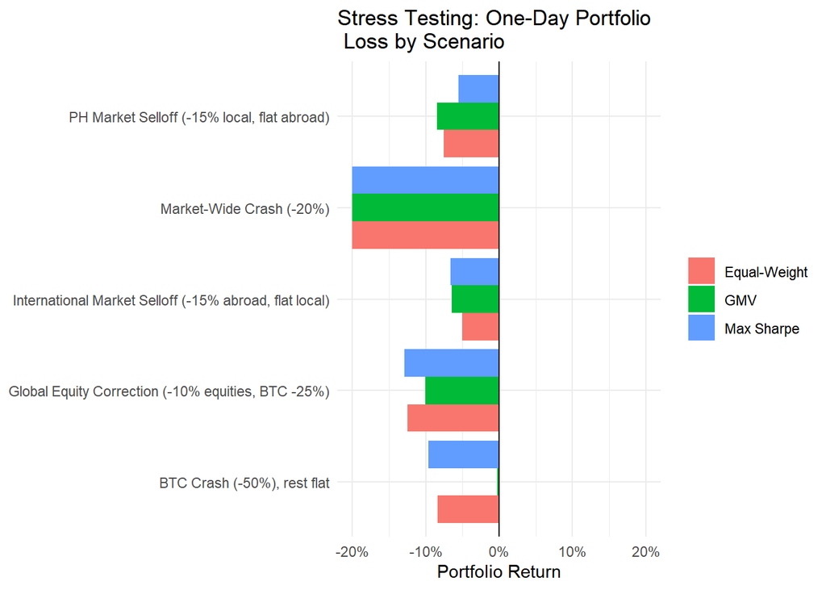

```r
max_abs <- stress_results |>
  pivot_longer(-Scenario, names_to = "Portfolio", values_to = "loss") |>
  pull(loss) |>
  abs() |>
  max(na.rm = TRUE)

stress_results |>
  pivot_longer(-Scenario, names_to = "Portfolio", values_to = "loss") |>
  ggplot(aes(x = Scenario, y = loss, fill = Portfolio)) +
  geom_col(position = "dodge") +
  geom_hline(yintercept = 0, color = "black", linewidth = 0.4) +
  coord_flip() +
  labs(title = "Stress Testing: One-Day Portfolio \n Loss by Scenario",
       x = NULL, y = "Portfolio Return", fill = NULL) +
  scale_y_continuous(labels = scales::percent,
                      limits = c(-max_abs, max_abs)) + theme_minimal()
```

Figure 6.3 lays all five scenarios out on one chart, and the pattern that emerges qualifies the “GMV is safest” conclusion drawn from the VaR, CVaR, and Monte Carlo sections above. GMV only pulls clearly ahead of the other two portfolios in the BTC crash scenario, where its near-zero crypto exposure protects it almost entirely; in the Philippine selloff scenario, that same concentration works against it, and GMV actually posts the worst loss of the three. Max Sharpe and Equal-Weight, by contrast, are more evenly exposed across scenarios, neither dominates nor lags dramatically regardless of which market segment is shocked. The overall implication for the recommendation below is that “lowest risk” depends on which risk is being asked about: GMV minimizes day-to-day statistical variance, but its concentration in Philippine equities leaves it exposed to a scenario-specific risk that VaR, CVaR, and Monte Carlo, all built from the same historical return distribution, would not have flagged on their own.

# 7. Executive Recommendation

Having evaluated all three portfolios across returns and volatility, our recommendation is guided primarily by the investor’s risk appetite and investment outlook since no single portfolio is objectively the “best” independent of investor context. We need to take into consideration that each portfolio is optimized based on certain objectives and needs to correlate directly with a specific goal an investor is vying for.

Say, if an investor were more conservative, prioritizing holding capital and looking to invest locally, then the Global Minimum Variance portfolio would be the most appropriate recommendation. GMV consistently maintains the lowest risk across evaluated measures (1.95% daily Historical VaR and 2.72% Expected Shortfall), while still maintaining substantial weight distributions for BDO, ICT, and SM. This is a direct result of GMV’s optimization objective, where it aims to minimize total portfolio variance over maximizing returns.

However, our primary recommendation would be the Maximum Sharpe portfolio, as it achieves the highest possible risk-adjusted return of the three portfolios. Although it consistently produces the highest VaR (2.50%–2.79% VaR versus 1.95%–2.21% for GMV) across measurements, this does not indicate poor performance, but rather proves how this elevated risk is compensated correspondingly by higher expected returns and a Sharpe ratio. Now comparing the growth rate of each portfolio, both the rebalanced and non-rebalanced Max Sharpe portfolios grew the most by a significant margin, further supporting Max Sharpe’s return optimized strategy.

We do acknowledge that the weights were calculated based on set defined risk-minimization or return-maximization objectives and historical data, and are thus not inclusive of overall preference and appetite. Although we do suggest Maximum Sharpe due to its historically backed reliability when it comes to risk-adjusted returns, markets still remain inherently unpredictable, and historical performance is not indicative of future performance. The recommended weight distribution only serves as a rational suggestion when accounting for an optimal risk to return ratio, they do not account for an individual investor’s personal risk tolerance, liquidity needs, or investment outlook. This recommendation purely serves as a data backed starting point for portfolio construction to be adapted towards individual preferences.

# 8. References

- Hayes, A. (2025). Financial Markets: Role in the Economy, Importance, Types, and Examples. https://www.investopedia.com/terms/f/financial-market.asp
- Gopalakrishnan, J. (2025, December 10). Stock investment risk: Understanding systematic and idiosyncratic risks. Encyclopedia Britannica. https://www.britannica.com/money/types-of-investment-risks
- Chen, J. (2025, July 9). Risk-Return Tradeoff: How the Investment Principle Works. Investopedia. https://www.investopedia.com/terms/r/riskreturntradeoff.asp The Investopedia Team. (2026, February 4). Modern Portfolio Theory: What MPT Is and How Investors Use It. https://www.investopedia.com/terms/m/modernportfoliotheory.asp
- Chen, J. (2026, July 20). Conditional Value at Risk (CVaR): Expert Guide, Uses, and Formula. https://www.investopedia.com/terms/c/conditional_value_at_risk.asp
- The Investopedia Team. (2024, November 26). Parametric Method in Value at Risk (VaR): Definition and Examples. https://www.investopedia.com/ask/answers/041715/what-variancecovariance-matrix-or-parametric-method-value-risk-var.asp
- R. Harper, D. (2025, November 25). Understanding Value at Risk (VaR): Explanation and Calculation Methods. Investopedia. https://www.investopedia.com/articles/04/092904.asp
- Kenton, W. (2026, March 24). Monte Carlo Simulation: What It Is, How It Works, History, 4 Key Steps. Investopedia. https://www.investopedia.com/terms/m/montecarlosimulation.asp